# Tutorial rapido jupyter notebook

## Estrutura

### Aplicativo jupyter notebook

O aplicativo jupyter notebook é uma aplicação cliente-servidor que permite editar e rodar documentos notebook via um browser. Ele também possui um dashboard.

### Notebook Dashboard

O dashboard de notebooks é o componente que é mostrado assim que abrimos o jupyter. Ele é utilizado principalmente para a interação com o sistema de arquivos e controle sobre os documentos notebooks e o aplicativo jupyter notebook.

### Documentos notebook

Os documentos notebook, são arquivos criados utilizando o aplicativo jupyter notebook. Eles podem conter tanto código executavel, dependente de um "notebook kernel", como elementos de texto e gráficos. Podemos dizer que eles são tanto documentos "human-readable" de uma análise quanto um documento executavel que performa a análise

### Notebook kernel

O notebook kernel é uma *engine* computacional que permite a execução do código contido no documento notebook. Para o curso utilizaremos uma *engine* python, porém poderiamos utilizar outras se fosse o caso.

## Células

O notebook jupyter é uma IDE baseada em células. Inicialmente temos 4 tipos, que podem ser incrementados com plugins:

### Markdown

- Latex -> $x = y_c^{\frac{2}{7}}$
- Execução python dentro do markdown -> 4

### Code

Células contendo código a ser executado na linguagem escolhida no kernel. Para o caso deste curso todos os kernels serão de python, porém poderia ser utilizado para outras linguagens.

### Heading

Deprecado, a forma correta de adicionar cabeçalhos agora é pelo padrao do markdown

### Raw nbconvert

Nbconvert é uma facilidade do jupyter que permite converter o notebook para outros formatos, como por exemplo o html que usamos com as informações de instalação. Essa célula nos permite colocar qualquer coisa que não deve ser convertida na hora dessa transformação. **Não é muito utilizado**

Essas células podem ser executadas em qualquer ordem (mesmo células de texto devem ser executadas para que sua formatação apareça), para isso voce pode usar o botao play no menu do topo, que é equivalente ao atalho CTRL+Enter.

```python
vetor = [1,2,3]
print("Teste de célula")
print("O vetor é ", vetor)
vetor
```

```
Teste de célula
O vetor é  [1, 2, 3]
```

```
[1, 2, 3]
```

```python
print("Teste de célula com função definida na célula seguinte")
myfunction(vetor)
```

```
Teste de célula com função definida na célula seguinte
```

```
[2, 3, 4]
```

```python
def myfunction(vetor):
    vetor_resposta = list()
    for elemento in vetor:
        vetor_resposta.append(elemento+1)
    return vetor_resposta
```

```python
print("Teste de célula com função definida na célula anterior")
myfunction(vetor)
```

```
Teste de célula com função definida na célula anterior
```

```
[2, 3, 4]
```

### Recuperando valores anteriores

Dado que o notebook te permite executar as células em qualquer ordem e a re-execução de uma célula, podemos querer saber o que tinha sido executado na ordem. Para isso podemos utilizar as variáveis In e Out

```python
for _index, values in enumerate(In):

    print("{}, In: {}".format(_index,values))
    if _index in Out.keys():
        print("Out: {}".format(Out[_index]))
```

```
0, In:
1, In: vetor = [1,2,3]
print("Teste de célula")
print("O vetor é ", vetor)
vetor
Out: [1, 2, 3]
2, In: print("Teste de célula com função definida na célula seguinte")
myfunction(vetor)
3, In: def myfunction(vetor):
    vetor_resposta = list()
    for elemento in vetor:
        vetor_resposta.append(elemento+1)
    return vetor_resposta
4, In: print("Teste de célula com função definida na célula anterior")
myfunction(vetor)
Out: [2, 3, 4]
5, In: print("Teste de célula com função definida na célula seguinte")
myfunction(vetor)
Out: [2, 3, 4]
6, In: for _index, values in enumerate(In):

    print("{}, In: {}".format(_index,values))
    if _index in Out.keys():
        print("Out: {}".format(Out[_index]))
```

## Extras do kernel do python

O kernel do python nos permite a utilização de alguns tipos de comando extra:

### Comandos de terminal

O kernel do python nos permite executar comandos shell (por exemplo, ls, ifconfig, conda install...) se incluirmos um **!** como por exemplo:

```python
!dir
```

```
Instalacao.html       requirements.txt
Instalacao.ipynb      Tutorial\ Jupyter\ notebook.html
Pandas.ipynb	      Tutorial\ Jupyter\ notebook.ipynb
requirements_pip.txt
```

```python
arquivos = !dir

print(arquivos)

message = "hello from Python"

!echo {message}
```

```
['/bin/bash: /home/cadu/anaconda3/envs/ml_ruy/lib/libtinfo.so.5: no version information available (required by /bin/bash)', 'Instalacao.html       requirements.txt', 'Instalacao.ipynb      Tutorial\\ Jupyter\\ notebook.html', 'Pandas.ipynb\t      Tutorial\\ Jupyter\\ notebook.ipynb', 'requirements_p…
hello from Python
```

### Mágicas

Também temos algumas "mágicas" que permitem acesso a outras ferramentas graças a adição de um ou dois **%**. Seguem alguns exemplos, e a lista completa pode ser encontrada [aqui](http://ipython.readthedocs.io/en/stable/interactive/magics.html):

```python
%whos
```

```
Variable     Type        Data/Info
----------------------------------
arquivos     SList       ['/bin/bash: /home/cadu/a<...>, 'requirements_pip.txt']
message      str         hello from Python
myfunction   function    <function myfunction at 0x7fabec1d8f28>
values       str         for _index, values in enu<...> {}".format(Out[_index]))
vetor        list        n=3
```

```python
%whos str
```

```
Variable   Type    Data/Info
----------------------------
message    str     hello from Python
values     str     for _index, values in enu<...> {}".format(Out[_index]))
```

```python
%time myfunction(vetor)
```

```
CPU times: user 0 ns, sys: 0 ns, total: 0 ns
Wall time: 11.2 µs
```

```
[2, 3, 4]
```

```python
%timeit myfunction(vetor)
```

```
The slowest run took 8.23 times longer than the fastest. This could mean that an intermediate result is being cached.
1000000 loops, best of 3: 709 ns per loop
```

### Help

Você também pode pedir informações sobre os objetos e metódos utilizando um ou dois pontos de interrogação ,**?**. Utilizando um você receberá o docstring daquele objeto. Utilizando dois é possível consultar até a definição de métodos.

```python
import matplotlib
matplotlib?
```

```python
myfunction??
```

### Exibição de gráficos

Usualmente a criação de gráficos em python utiliza matplotlib. Para que esses gráficos apareçam no seu notebook, você precisa utilizar a mágica %matplotlib. Existem dois tipos

- %matplotlib inline: simplesmente joga o gráfico gerado na saida do notebook.
- %matplotlib notebook: gera um javascript que engloba o gráfico e permite iteração com o gráfico

```
Gráfico inline
```

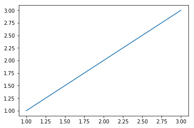

```python
import matplotlib.pyplot as plt
%matplotlib inline
plt.plot(vetor,vetor)
print("Gráfico inline ")
```

[figure not shown]

```
Gráfico com javascript
```

```python
%matplotlib notebook
plt.plot(vetor,vetor,label="x=y")
plt.legend()
plt.show()
print("Gráfico com javascript")
```

```python
plt.plot([1,2,3],[1.5,1.5,1.5], label="y=1.5");
plt.legend();
```

```python
plt.plot([1,2,3],[1,4,9], label="y=x^2")
plt.legend();
```

[figure not shown]

```
Gráfico com javascript
```

```python
import seaborn as sns
plt.plot(vetor,vetor,label="x=y")
plt.legend()
plt.show()
print("Gráfico com javascript")
```

```python
plt.plot([1,2,3],[1.5,1.5,1.5], label="y=1.5");
plt.legend();
```

```python
plt.plot([1,2,3],[1,4,9], label="y=x^2")
plt.legend();
```